# Lapse Prediction

2022-10-02

### Load Required Libraries

```r
Sys.setenv(TZ = 'GMT')

# libraries
library(tidyverse)
library(lubridate)
library(tidymodels)
library(janitor)
```

### Read in data

```r
# Load data
train <- read_csv('Zimnat Insurance Data/train.csv') %>% clean_names()
client <- read_csv('Zimnat Insurance Data/client_data.csv') %>% clean_names()
```

```r
payment_his <- read_csv('Zimnat Insurance Data/payment_history.csv')  %>% clean_names()
policy <- read_csv('Zimnat Insurance Data/policy_data.csv')  %>% clean_names()
```

### Inspect and clean data

#### Train

Contains policy data as well as whether or not the policy had lapsed and the year in which it lapsed. Policies that had not lapsed by the end of 2019 have blank entries for the lapse and lapse year column.

```r
# Get a summary of the train data
train %>% summary()
```

```
##   policy_id             lapse         lapse_year
##  Length:51685       Min.   :1       Min.   :2017
##  Class :character   1st Qu.:1       1st Qu.:2018
##  Mode  :character   Median :1       Median :2019
##                     Mean   :1       Mean   :2019
##                     3rd Qu.:1       3rd Qu.:2019
##                     Max.   :1       Max.   :2019
##                     NA's   :43707   NA's   :43707
```

From the summary above, we see there are about `43707` policies that have not lapsed as of 2019. These are represented by the `NA's`. We will fill the `NA's` in the `lapse` column with `0` to indicate these are active policies and also fill the `NA's` in the `lapse_year` column with `9999` since we don’t know when those policies will lapse.

```r
train_filled <- train %>%
    mutate(
        lapse      = as_factor(if_else(is.na(lapse),0,lapse)),
        lapse_year = as_factor(if_else(is.na(lapse_year),9999,lapse_year))
        )
```

Get a sense of the proportion of lapsed vs non-lapsed policies

```r
train_filled %>%
    group_by(lapse) %>%
    summarise(
    no_policies = n(),
    `prop_%`  = (n()/nrow(.)) * 100

)
```

```
## # A tibble: 2 x 3
##   lapse no_policies `prop_%`
##   <fct>       <int>    <dbl>
## 1 0           43707     84.6
## 2 1            7978     15.4
```

```r
# train_filled %>%
#     ggplot(aes(x = lapse, fill = lapse_year)) +
#     geom_bar(position = 'dodge') + theme_minimal() +
#     ylab('Number of policies')
```

### Client

```r
client %>% head()
```

```
## # A tibble: 6 x 7
##   policy_id   nph_title nph_lastname         nph_sex nph_birthdate nad_address1
##   <chr>       <chr>     <chr>                <chr>           <dbl> <chr>
## 1 PID_P1UHZRT Ms.       <NA>                 F                1997 ADDRESS1_WSR~
## 2 PID_GUI5GQJ Mr.       NPH_LASTNAME_L256UFJ M                1954 ADDRESS1_WSR~
## 3 PID_LECMECN Mr.       NPH_LASTNAME_3YMQL4X M                1923 ADDRESS1_WSR~
## 4 PID_BCSLJHG Mrs.      NPH_LASTNAME_IYMYRSV F                1973 <NA>
## 5 PID_YA1G5R6 Ms.       NPH_LASTNAME_HJ3MUUR F                1935 ADDRESS1_WSR~
## 6 PID_0VVJ1WY Mr.       NPH_LASTNAME_RPKZGGM M                2012 ADDRESS1_WSR~
## # ... with 1 more variable: nad_address2 <chr>
```

```r
client_clean <- client %>% distinct() %>%
    mutate(
        gender        = as_factor(nph_sex),
        age           = 2020 - nph_birthdate,
        has_address_1 = as_factor(!is.na(nad_address1)),
        has_address_2 = as_factor(!is.na(nad_address2)),

    ) %>% select(policy_id, gender,age,has_address_1,has_address_2) %>% distinct

client_clean %>% head()
```

```
## # A tibble: 6 x 5
##   policy_id   gender   age has_address_1 has_address_2
##   <chr>       <fct>  <dbl> <fct>         <fct>
## 1 PID_P1UHZRT F         23 TRUE          TRUE
## 2 PID_GUI5GQJ M         66 TRUE          TRUE
## 3 PID_LECMECN M         97 TRUE          TRUE
## 4 PID_BCSLJHG F         47 FALSE         FALSE
## 5 PID_YA1G5R6 F         85 TRUE          TRUE
## 6 PID_0VVJ1WY M          8 TRUE          TRUE
```

### Payment history

Contains payment history up to the end of 2018 tied to Policy ID. Payments made in 2019 are not provided.

```r
#Get a glimpse of the data
payment_his %>% head()
```

```
## # A tibble: 6 x 5
##   policy_id   amountpaid datepaid         postdate         premiumduedate
##   <chr>            <dbl> <chr>            <chr>            <chr>
## 1 PID_VTBGKIZ      1287. 29/12/2018 00:00 29/12/2018 00:00 11/01/2018 00:00
## 2 PID_9J9V5YQ         0  10/04/2017 00:00 10/04/2017 17:30 10/01/2017 00:00
## 3 PID_RT2SI59      3436. 24/12/2018 00:00 28/12/2018 00:00 01/01/2019 00:00
## 4 PID_NCXO0DU      3196. 26/06/2018 00:00 26/06/2018 00:00 07/01/2018 00:00
## 5 PID_FZYCT7V         0  12/03/2018 00:00 12/03/2018 17:09 12/01/2018 00:00
## 6 PID_O6886U4         0  29/12/2018 00:00 29/12/2018 22:00 11/01/2018 00:00
```

```r
# Convert the dates to the right data type, remove duplicate entries and 0 payments,add two new columns, number of days before and after the payment due date.
payment_his_clean <- payment_his %>%
    select(policy_id,premiumduedate,datepaid,amountpaid) %>%
    mutate(premiumduedate          = date(mdy_hm(premiumduedate)),
           datepaid                = date(dmy_hm(datepaid)),
           days_btwn_dates         = as.double(premiumduedate - datepaid)
           ) %>%
    filter(amountpaid != 0 ) %>%
    distinct() %>%
    mutate(
    days_b4_due_date         = if_else(days_btwn_dates > 0,days_btwn_dates,0),
    days_to_next_payment     = if_else(days_btwn_dates < 0,days_btwn_dates * -1,0)
    ) %>% select(-days_btwn_dates)

payment_his_clean_summary <- payment_his_clean %>%
    group_by(policy_id) %>%
    summarise(num_payments = n(),
              total_premium_payment    = sum(amountpaid),
              avg_premium_payment      = mean(amountpaid),
              avg_days_to_next_payment = round(mean(days_to_next_payment)),
              avg_days_b4_due_date     = round(mean(days_b4_due_date)))


# Inspect one policy
# payment_his_clean %>%
#     select(policy_id,premiumduedate,datepaid,days_to_next_payment,days_b4_due_date,amountpaid) %>%
#     filter(policy_id == 'PID_QR15RBQ') %>%
#     arrange(premiumduedate,datepaid)
```

### Policy

We noticed policies with clf_lifecd = 1 have complete information regarding the sum assured and premium amount. This is because the poilcy us tied to the main life.

```r
policy %>% head()
```

```
## # A tibble: 6 x 14
##   policy_id   np2_effectdate ppr_prodcd      npr_premium nph_lastname clf_lifecd
##   <chr>       <chr>          <chr>                 <dbl> <chr>             <dbl>
## 1 PID_EPZDSP8 01/09/2019     PPR_PRODCD_B2K~        266. NPH_LASTNAM~          2
## 2 PID_6M6G9IB 01/08/2018     PPR_PRODCD_64Q~       2795. NPH_LASTNAM~          1
## 3 PID_UL0F7LH 01/08/2017     PPR_PRODCD_KOF~       2493. NPH_LASTNAM~          1
## 4 PID_TRGUBTU 01/04/2018     PPR_PRODCD_KOF~       3983. NPH_LASTNAM~          1
## 5 PID_TODLPIB 01/12/2019     PPR_PRODCD_KOF~       1144. NPH_LASTNAM~          3
## 6 PID_T31UO9L 01/02/2017     PPR_PRODCD_165~       1244. NPH_LASTNAM~          1
## # ... with 8 more variables: nsp_subproposal <dbl>, npr_sumassured <dbl>,
## #   nlo_type <chr>, nlo_amount <dbl>, aag_agcode <chr>, pcl_locatcode <chr>,
## #   occupation <chr>, category <chr>
```

```r
# Main life
main_life <- policy %>% filter(
    clf_lifecd == 1 & !is.na(npr_sumassured) & !is.na(nlo_amount)) %>%
    distinct()



main_life_bio <-  main_life %>% select(policy_id,
                 pcl_locatcode,occupation,category ) %>%
    mutate(
      pcl_locatcode           = as_factor(pcl_locatcode),
      occupation              = as_factor(occupation),
      category                = as_factor(category)
    ) %>% distinct()



policy_details <- policy %>%
    group_by(policy_id) %>%
    summarise(
        num_prod = length(levels(as_factor(ppr_prodcd))),
        num_nlo_type = length(levels(as_factor(nlo_type))),
        num_aag_agcode = length(levels(as_factor(aag_agcode))),
        npr_premium = sum(npr_premium,na.rm = TRUE),
        nlo_amount  = sum(nlo_amount,na.rm = TRUE),
        npr_sumassured = sum(npr_sumassured,na.rm = TRUE),
        np2_effectdate = max(np2_effectdate),
        num_clf_lifecd = length(levels(as_factor(clf_lifecd)))
    )

policy_clean <- main_life_bio %>%
    left_join(policy_details, by = 'policy_id')

policy_clean
```

```
## # A tibble: 51,685 x 12
##    policy_id   pcl_locatcode         occupation   category num_prod num_nlo_type
##    <chr>       <fct>                 <fct>        <fct>       <int>        <int>
##  1 PID_6M6G9IB PCL_LOCATCODE_7VFS3EQ OCCUPATION_~ CATEGOR~        1            2
##  2 PID_UL0F7LH PCL_LOCATCODE_SKPRCR4 OCCUPATION_~ CATEGOR~        2            2
##  3 PID_TRGUBTU PCL_LOCATCODE_SPQHMX5 OCCUPATION_~ CATEGOR~        2            2
##  4 PID_T31UO9L PCL_LOCATCODE_295LOO6 OCCUPATION_~ CATEGOR~        1            1
##  5 PID_QXW49OG PCL_LOCATCODE_0T6GYGX OCCUPATION_~ CATEGOR~        2            2
##  6 PID_R62PCDI PCL_LOCATCODE_O6OBSFL OCCUPATION_~ CATEGOR~        2            2
##  7 PID_A0E4AZJ PCL_LOCATCODE_O6OBSFL OCCUPATION_~ CATEGOR~        1            2
##  8 PID_MCF7XJZ PCL_LOCATCODE_O6OBSFL OCCUPATION_~ CATEGOR~        1            1
##  9 PID_NMLUZAW PCL_LOCATCODE_7VFS3EQ OCCUPATION_~ CATEGOR~        1            2
## 10 PID_PKYVK2M PCL_LOCATCODE_SPQHMX5 OCCUPATION_~ CATEGOR~        2            2
## # ... with 51,675 more rows, and 6 more variables: num_aag_agcode <int>,
## #   npr_premium <dbl>, nlo_amount <dbl>, npr_sumassured <dbl>,
## #   np2_effectdate <chr>, num_clf_lifecd <int>
```

### Merge the data

```r
train_filled %>% head()
```

```
## # A tibble: 6 x 3
##   policy_id   lapse lapse_year
##   <chr>       <fct> <fct>
## 1 PID_XV54OVD 1     2017
## 2 PID_DC4MRS6 1     2017
## 3 PID_GS4IF0B 1     2017
## 4 PID_30QO4UU 1     2017
## 5 PID_TZO5U7O 1     2017
## 6 PID_RVEYTQ9 1     2017
```

```r
training_data <- train_filled %>%
    #left_join(client_clean,by = 'policy_id') %>%
    left_join(payment_his_clean_summary,by = 'policy_id' ) %>%
    left_join(policy_clean, by = 'policy_id') %>%
    filter(!is.na(num_payments)) %>%
    mutate(
        lapse = fct_rev(lapse)
        )


training_data %>% colnames()
```

```
##  [1] "policy_id"                "lapse"
##  [3] "lapse_year"               "num_payments"
##  [5] "total_premium_payment"    "avg_premium_payment"
##  [7] "avg_days_to_next_payment" "avg_days_b4_due_date"
##  [9] "pcl_locatcode"            "occupation"
## [11] "category"                 "num_prod"
## [13] "num_nlo_type"             "num_aag_agcode"
## [15] "npr_premium"              "nlo_amount"
## [17] "npr_sumassured"           "np2_effectdate"
## [19] "num_clf_lifecd"
```

```r
training_data <- training_data %>%
    mutate(
        end_date   = ymd(case_when(
            lapse_year == '2017' ~ '2017-12-31 ',
            lapse_year == '2018' ~ '2018-12-31 ',
            lapse_year == '2019' ~ '2019-12-31 ',
            TRUE                 ~ '2020-12-31 ')),
        policy_duration = end_date - dmy(np2_effectdate)

    ) %>% select(-end_date,-np2_effectdate,everything())

training_data %>%
    head()
```

```
## # A tibble: 6 x 21
##   policy_id   lapse lapse_year num_payments total_premium_paym~ avg_premium_pay~
##   <chr>       <fct> <fct>             <int>               <dbl>            <dbl>
## 1 PID_XV54OVD 1     2017                  1               2491.            2491.
## 2 PID_DC4MRS6 1     2017                  1               2584.            2584.
## 3 PID_GS4IF0B 1     2017                  1               3929.            3929.
## 4 PID_30QO4UU 1     2017                  2               4843.            2421.
## 5 PID_TZO5U7O 1     2017                  1               2613.            2613.
## 6 PID_RVEYTQ9 1     2017                  4               9743.            2436.
## # ... with 15 more variables: avg_days_to_next_payment <dbl>,
## #   avg_days_b4_due_date <dbl>, pcl_locatcode <fct>, occupation <fct>,
## #   category <fct>, num_prod <int>, num_nlo_type <int>, num_aag_agcode <int>,
## #   npr_premium <dbl>, nlo_amount <dbl>, npr_sumassured <dbl>,
## #   num_clf_lifecd <int>, policy_duration <drtn>, np2_effectdate <chr>,
## #   end_date <date>
```

```r
training_data <- training_data  %>%
    # Selecting columns of interest, after reviewing the variable importance plot from previous models.
    select(
    policy_id,lapse,num_payments,avg_premium_payment,pcl_locatcode,
    num_prod,num_nlo_type,num_aag_agcode,avg_days_to_next_payment,avg_days_b4_due_date,num_clf_lifecd,
    npr_sumassured,occupation,policy_duration)
# gender,age
```

### Explore the data

See data profile report.

```r
# library(DataExplorer)
# training_data %>% create_report()
#
# write_csv(training_data,'data.csv')
```

### Split data into train and test using stratified sampling

Stratified sampling ensures we have a required representation of the lapses both in the training and the test data. Train with 70% of the data and evaluate the model on the remaining 30%.

```r
set.seed(502) # Ensure our split is reproducible
data_split <- initial_split(training_data,prop = 0.70, strata = lapse)


train_data <- training(data_split)

testing_data <- testing(data_split)
```

### Create a data processing pipeline

Create a workflow made up of a preprocessing recipe and a logistic regression model. The preprocessing step will ensure we have a pipeline that can handle unseen categories in future data.

```r
# Recipe
rec <- train_data  %>%
    recipe(lapse ~.) %>%
    update_role(policy_id, new_role = 'ID') %>%
    step_novel(all_nominal_predictors()) %>%
    step_other(all_nominal_predictors())

# Model
logistic_model<- logistic_reg() %>%
        set_engine("glm") %>%
        set_mode("classification")


# Workflow - combine recipe and model
wf_model <- workflow(rec,logistic_model)
```

### Evaluate model

Model is trained using a 5-fold cross validation - we split our training data into 5 non overlapping sets and trained the model on each of them to see how it performs.

```r
set.seed(100)

cv_folds <-  vfold_cv(train_data, v = 5,strata = lapse)


log_res <-
  wf_model %>%
  fit_resamples(
    resamples = cv_folds,
    metrics = metric_set(
      recall, precision, f_meas,
      accuracy, kap,
      roc_auc, sens, spec),
    control = control_resamples(
      save_pred = TRUE)
    )
```

```
## ! Fold1: preprocessor 1/1, model 1/1: glm.fit: fitted probabilities numerically 0 or 1 occurred
```

```
## ! Fold2: preprocessor 1/1, model 1/1: glm.fit: fitted probabilities numerically 0 or 1 occurred
```

```
## ! Fold3: preprocessor 1/1, model 1/1: glm.fit: fitted probabilities numerically 0 or 1 occurred
```

```
## ! Fold4: preprocessor 1/1, model 1/1: glm.fit: fitted probabilities numerically 0 or 1 occurred
```

```
## ! Fold5: preprocessor 1/1, model 1/1: glm.fit: fitted probabilities numerically 0 or 1 occurred
```

### Results of cross-validation

The results of our model on the 5 different data sets are averaged and the result is presented below. Our model performed well with an accuracy of approximately 95% across the 5 subsets it was trained on.

```r
log_res %>%  collect_metrics(summarize = TRUE)
```

```
## # A tibble: 8 x 6
##   .metric   .estimator  mean     n std_err .config
##   <chr>     <chr>      <dbl> <int>   <dbl> <chr>
## 1 accuracy  binary     0.945     5 0.00242 Preprocessor1_Model1
## 2 f_meas    binary     0.868     5 0.00566 Preprocessor1_Model1
## 3 kap       binary     0.834     5 0.00718 Preprocessor1_Model1
## 4 precision binary     0.899     5 0.00823 Preprocessor1_Model1
## 5 recall    binary     0.840     5 0.00727 Preprocessor1_Model1
## 6 roc_auc   binary     0.971     5 0.00174 Preprocessor1_Model1
## 7 sens      binary     0.840     5 0.00727 Preprocessor1_Model1
## 8 spec      binary     0.974     5 0.00241 Preprocessor1_Model1
```

```r
log_pred <-
  log_res %>%
  collect_predictions()
```

### Graphical Representation of Cross-validation result

The plot below shows the ROC (Receiver Operating Characterisitc) curves of our model for each of the five subsets trained on. The closer the curve is to the top left, the better.

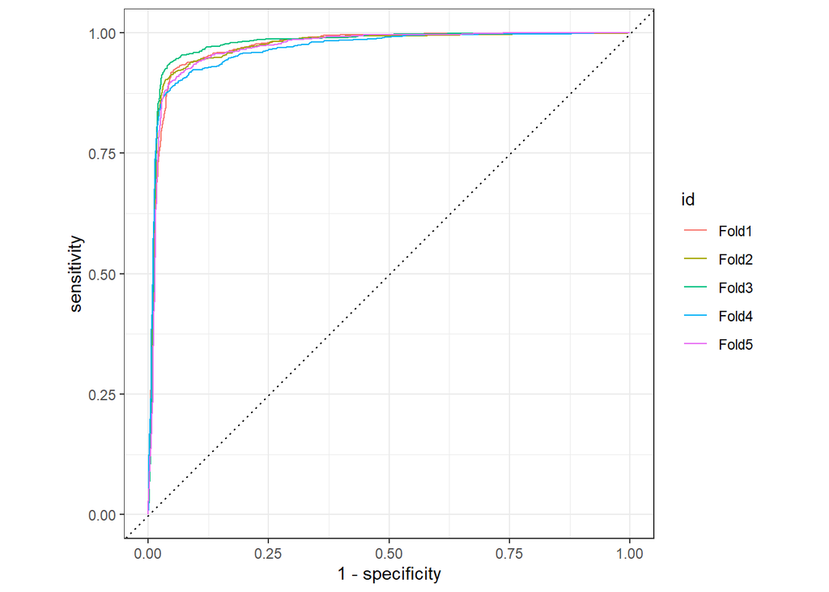

```r
log_pred %>%
  group_by(id) %>% # id contains our folds
  roc_curve(lapse, .pred_1) %>%
  autoplot()
```

### Distribution of our predictions

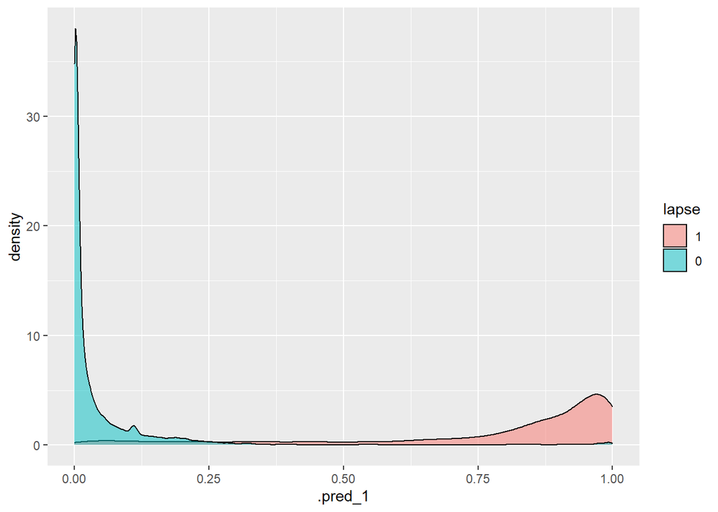

```r
log_pred %>%
  ggplot() +
  geom_density(aes(x = ,.pred_1,
                   fill = lapse),
               alpha = 0.5)
```

### Evaluation on a test set

Our model is then trained on the entire training set and evaluated using the test set.

```r
last_fit_log <- last_fit(wf_model,
                        split = data_split,
                        metrics = metric_set(
                          accuracy,precision,recall, f_meas,
                          kap,roc_auc, sens, spec)
                        )
```

```
## ! train/test split: preprocessor 1/1, model 1/1: glm.fit: fitted probabilities numerically 0 or 1 occurred
```

### Final model details

```r
last_fit_log$.workflow
```

```
## [[1]]
## == Workflow [trained] ==========================================================
## Preprocessor: Recipe
## Model: logistic_reg()
##
## -- Preprocessor ----------------------------------------------------------------
## 2 Recipe Steps
##
## * step_novel()
## * step_other()
##
## -- Model -----------------------------------------------------------------------
##
## Call:  stats::glm(formula = ..y ~ ., family = stats::binomial, data = data)
##
## Coefficients:
##                        (Intercept)                        num_payments
##                         -5.110e+00                          -1.134e-01
##                avg_premium_payment  pcl_locatcodePCL_LOCATCODE_SKPRCR4
##                         -6.054e-05                          -2.156e-01
## pcl_locatcodePCL_LOCATCODE_SPQHMX5  pcl_locatcodePCL_LOCATCODE_295LOO6
##                         -2.421e-02                          -2.158e+00
## pcl_locatcodePCL_LOCATCODE_0T6GYGX  pcl_locatcodePCL_LOCATCODE_O6OBSFL
##                         -4.953e-01                          -6.288e-01
## pcl_locatcodePCL_LOCATCODE_PI2W0SA  pcl_locatcodePCL_LOCATCODE_PEU5TF2
##                         -4.001e-01                          -2.352e+00
##                 pcl_locatcodeother                            num_prod
##                         -5.550e-01                          -1.798e+00
##                       num_nlo_type                      num_aag_agcode
##                          8.443e-01                          -4.851e-01
##           avg_days_to_next_payment                avg_days_b4_due_date
##                         -1.435e-02                          -2.902e-04
##                     num_clf_lifecd                      npr_sumassured
##                         -1.460e-01                           1.292e-06
##       occupationOCCUPATION_NNHJ7XV        occupationOCCUPATION_WI64CIY
##                          1.043e-01                          -2.449e-01
##                    occupationother                     policy_duration
##                         -1.622e-01                           1.297e-02
##
## Degrees of Freedom: 22534 Total (i.e. Null);  22513 Residual
## Null Deviance:       23500
## Residual Deviance: 7702  AIC: 7746
```

### Inspect our model drivers

The variable importance plot helps us understand the factors that influence our model’s decision. From the plot below showing the top 15 variables that influence our model, we see policy_duration and the average number of days to the next payment are significant factors that determine the likelihood of a policy lapsing.

The top 6 influencers can be grouped into policy characteristics eg. policy duration, number of products and the sum assured and the premium payment details which include the average premium payment, number of payments to be made and the average number of days to the next payment.

The branch where a policy was sold also seems to have an influence on the likelihood of a policy to lapse.

Client details such as age and gender were not key factors of a policy’s likelihood to lapse and were omitted from the final model.

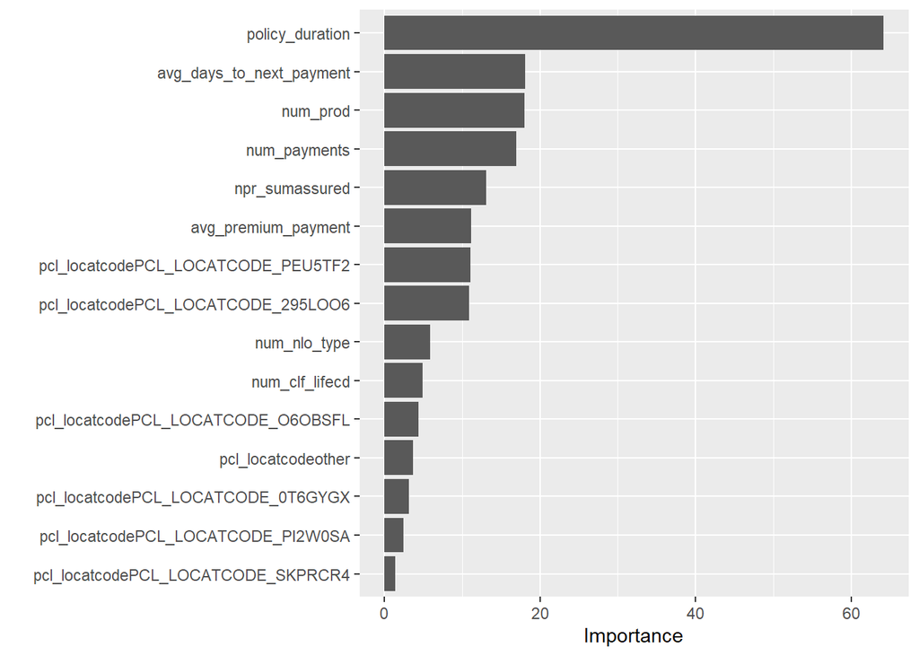

```r
library(vip)
last_fit_log %>%
  pluck(".workflow", 1) %>%
  extract_fit_parsnip() %>%
  vip(num_features = 15)
```

### Confusion Matrix

The confusion matrix/contingency table below gives us another visual representation of our models prediction against the true lapse occurrences. From the plot, we see our model made 171 false predictions asserting that the policies would lapse when in fact they did not. This constitutes a type 1 error. On the other hand, our model failed to accurately predict 328 policies that did lapse constituting a type 2 error.

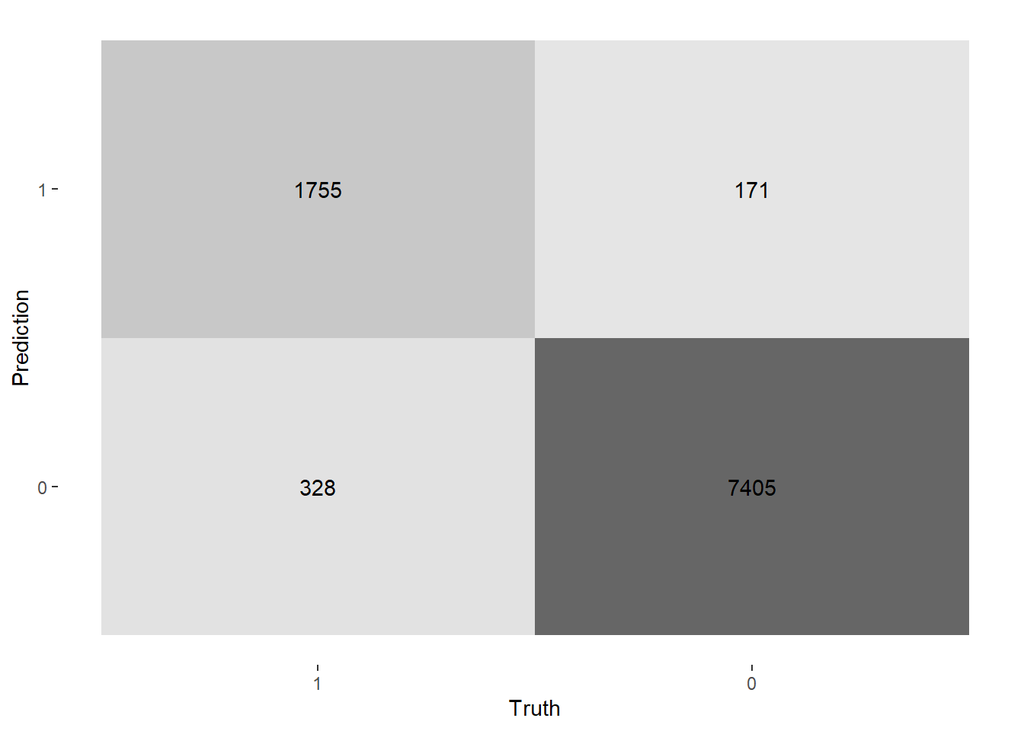

```r
last_fit_log %>%
  collect_predictions() %>%
  conf_mat(lapse, .pred_class) %>%
  autoplot(type = "heatmap")
```

Since our goal is to accurately predict lapses, our focus is on minimizing the number of false negatives (type 2 error) as this underestimates the potential losses the insurance company will incur as a result of lapses we were unable to predict.

The metric that captures this phenomenon is the Recall, it measures the fraction of relevant instances(in our case lapses) that were identified. Hence our model will be considered very good if it has a sufficiently high recall score.

### Model performance metrics

From the table below, we see our final model has similar performance as the average cross-validation score. Again, although the overall accuracy of our model is 95%, we notice our model’s recall score is 84.3% which good but can be improved further.

```r
last_fit_log %>%
  collect_metrics()
```

```
## # A tibble: 8 x 4
##   .metric   .estimator .estimate .config
##   <chr>     <chr>          <dbl> <chr>
## 1 accuracy  binary         0.948 Preprocessor1_Model1
## 2 precision binary         0.911 Preprocessor1_Model1
## 3 recall    binary         0.843 Preprocessor1_Model1
## 4 f_meas    binary         0.876 Preprocessor1_Model1
## 5 kap       binary         0.843 Preprocessor1_Model1
## 6 sens      binary         0.843 Preprocessor1_Model1
## 7 spec      binary         0.977 Preprocessor1_Model1
## 8 roc_auc   binary         0.972 Preprocessor1_Model1
```

### Final ROC-AUC

Below is our final models ROC curve with an AUC (Area Under the Curve) of approximately 0.97. The dotted diagonal line indicates the performance of a model similar to a random guess while a model with perfect classification has an AUC of 1. From the plot below, our model is significantly better than relying on a random guess and can be relied upon to predict policies likely to lapse.

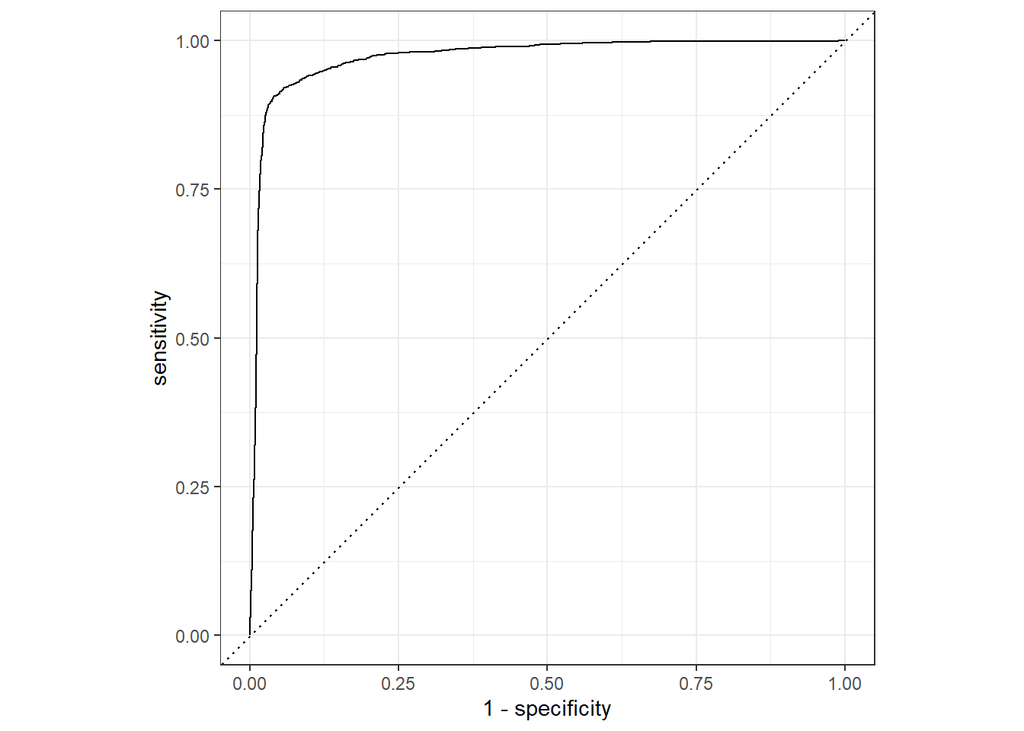

```r
last_fit_log %>%
  collect_predictions() %>%
  roc_curve(lapse, .pred_1) %>%
  autoplot()
```

### Prediction results

```r
results <- testing_data %>%
  select(policy_id) %>%
  bind_cols(last_fit_log$.predictions) %>%
    select(policy_id,.pred_class,lapse,.pred_1)

set.seed(1213)
results %>% sample_n(10)
```

```
## # A tibble: 10 x 4
##    policy_id   .pred_class lapse  .pred_1
##    <chr>       <fct>       <fct>    <dbl>
##  1 PID_A4D6G0Q 1           0     0.992
##  2 PID_6D9DKTG 0           0     0.0133
##  3 PID_EB7RJ0V 0           0     0.000293
##  4 PID_DI67I0E 0           0     0.0205
##  5 PID_SYC3RNR 1           1     0.923
##  6 PID_T15PGO4 0           0     0.000212
##  7 PID_C8B9BFN 1           1     0.918
##  8 PID_X98NR8U 0           0     0.00534
##  9 PID_NVSPRCK 1           1     0.991
## 10 PID_OB9YD6Q 0           0     0.00330
```

```r
write_csv(results,'predictions.csv')
```